# UC00198_Waste_Management_And_Health_Risks

# Waste Composition Over Time (Top Streams + Other) — Stacked Area

#### Datasets & columns used

- `df_waste` monthly table: time column (`month` or `date`) and stream columns: `residential`, `commingled_recycling`, `mattresses`, `street_sweepings`, `public_litter_bins`, `dumped_rubbish`, `cardboard`, `hardwaste_to_landfill`, `hardwaste_recovered`, `hardwaste_total`, `green_waste`.
- We plot from a prepared matrix `monthly_by_type` (index = month, columns = streams).

#### What the code does

```
Share of total by stream (window):
residential             51.4%
commingled_recycling    16.2%
other                   10.5%
mattresses               8.5%
street_sweepings         7.0%
public_litter_bins       6.5%
dtype: object

Total waste change over window: 20.7%
```

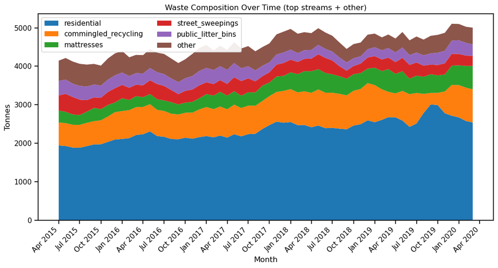

```python
mbt = monthly_by_type.sort_index().rolling(3, min_periods=1).mean()  # light smooth
win = mbt.iloc[-60:] if len(mbt)>60 else mbt
top = win.sum().sort_values(ascending=False).head(5).index
plot_df = win[top].copy(); plot_df["other"] = win.drop(columns=top, errors="ignore").sum(axis=1)
import matplotlib.dates as mdates

contrib = (plot_df.sum() / plot_df.sum().sum()).sort_values(ascending=False)
tot_series = plot_df.sum(axis=1)
chg_pct = (tot_series.iloc[-1] - tot_series.iloc[0]) / tot_series.iloc[0] * 100

fig, ax = plt.subplots(figsize=(11,6))
ax.stackplot(plot_df.index, plot_df.T.values, labels=plot_df.columns)
ax.set_title("Waste Composition Over Time (top streams + other)")
ax.set_xlabel("Month"); ax.set_ylabel("Tonnes")
ax.legend(loc="upper left", ncol=2, frameon=True, framealpha=0.9)

ax = plt.gca()
ax.xaxis.set_major_locator(mdates.MonthLocator(bymonth=[1,4,7,10]))  # Jan/Apr/Jul/Oct
ax.xaxis.set_major_formatter(mdates.DateFormatter('%b %Y'))          # e.g., Jan 2018
plt.setp(ax.get_xticklabels(), rotation=45, ha='right')
plt.tight_layout()


print("Share of total by stream (window):")
print((contrib*100).round(1).astype(str) + "%")
print(f"\nTotal waste change over window: {chg_pct:.1f}%")
```

#### Conclusion

Residential (51.4%) and Commingled recycling (16.2%) dominate the mix; total waste rose ~20.7% over the window. Peaks are largely driven by these streams, indicating where operational focus yields the greatest return.

# Risk Matrix — Workload vs Speed (by suburb)

#### Why this visualisation?

We need to **prioritise suburbs for action** by looking at two things at once: *workload* (complaints volume) and *service speed* (avg resolution days). A quadrant scatter splits both metrics at their medians so the **top-right quadrant** (high load + slow resolution) immediately shows the *highest-risk areas*.

#### Datasets & columns used

- `comp_m` (built from `df_complaints` by month & suburb):
  - **x** = `complaints_per_10k` (avg) if available, else **avg monthly complaints** (proxy).
  - **y** = `avg_resolution_days` (avg days to close per suburb).
  - **total** = total complaints per suburb (used for bubble sizes).

#### What the code does (in 2–3 lines)

It aggregates complaint rate and speed per suburb, computes median cut-lines, then plots a bubble scatter highlighting the **top-right** (high-load & slow) suburbs and annotates the most at-risk names. It also shows quadrant counts to summarise distribution.

1. **Build the risk table:** From `comp_m`, create a per-suburb frame with `x` (workload), `y` (avg resolution days), and `total` (for bubble size). Fall back to avg monthly complaints if per-10k isn’t available.
2. **Median split:** Compute `x_med` and `y_med` to define the four quadrants.
3. **Bubble sizing & score:** Scale bubbles by `total`. Build a simple composite `score` (z-scaled x+y) to rank labels inside the top-right quadrant.
4. **Select high-risk points:** Flag suburbs where `x ≥ x_med` and `y ≥ y_med` as the highest-risk set.
5. **Plot:** Draw a scatter for “other” quadrants and a highlighted scatter for “high load + slow”. Add dashed median lines, grid, labels, and legend.
6. **Annotate:** Label the top few (e.g., 5) highest-risk suburbs by `score` to avoid clutter.
7. **Quadrant counts:** Print the number of suburbs in each quadrant (context for how many are high-risk vs high-performing).

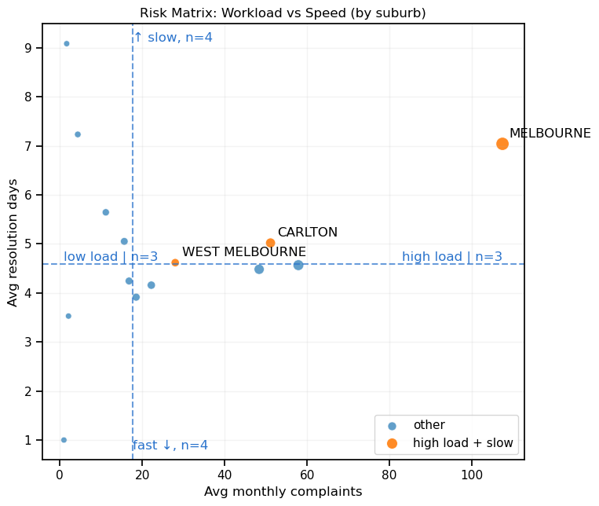

```
Top-right (high load + slow) suburbs: ['MELBOURNE', 'CARLTON', 'WEST MELBOURNE']
```

```python
import numpy as np
import matplotlib.pyplot as plt

if "complaints_per_10k" in comp_m.columns:
    risk = comp_m.groupby("suburb").agg(
        x=("complaints_per_10k", "mean"),
        y=("avg_resolution_days", "mean"),
        total=("complaints", "sum")
    ).dropna()
    xlabel = "Complaints per 10k (avg)"
else:
    risk = comp_m.groupby("suburb").agg(
        x=("complaints", "mean"),
        y=("avg_resolution_days", "mean"),
        total=("complaints", "sum")
    ).dropna()
    xlabel = "Avg monthly complaints"

x_med, y_med = risk["x"].median(), risk["y"].median()

size = 30 + 120 * (risk["total"] / (risk["total"].max() if risk["total"].max() else 1))
xz = (risk["x"] - x_med) / (risk["x"].std(ddof=0) + 1e-9)
yz = (risk["y"] - y_med) / (risk["y"].std(ddof=0) + 1e-9)
risk["score"] = xz + yz

hi = (risk["x"] >= x_med) & (risk["y"] >= y_med)

plt.figure(figsize=(7.8, 6.6))

plt.scatter(risk.loc[~hi, "x"], risk.loc[~hi, "y"],
            s=size[~hi], alpha=0.7, edgecolor="white", linewidth=0.6, label="other")

plt.scatter(risk.loc[hi, "x"],  risk.loc[hi, "y"],
            s=size[hi], alpha=0.9, edgecolor="white", linewidth=0.9, label="high load + slow")

plt.axvline(x_med, ls="--", color="#2a73cc", alpha=0.7)
plt.axhline(y_med, ls="--", color="#2a73cc", alpha=0.7)

plt.xlabel(xlabel)
plt.ylabel("Avg resolution days")
plt.title("Risk Matrix: Workload vs Speed (by suburb)")
plt.legend(loc="lower right")
plt.grid(alpha=.15)

for sub in risk[hi].sort_values("score", ascending=False).head(5).index:
    plt.annotate(sub.upper(), (risk.loc[sub, "x"], risk.loc[sub, "y"]),
                 xytext=(6, 6), textcoords="offset points")

q1 = ((risk["x"] <  x_med) & (risk["y"] >= y_med)).sum()
q2 = ((risk["x"] >= x_med) & (risk["y"] >= y_med)).sum()
q3 = ((risk["x"] <  x_med) & (risk["y"] <  y_med)).sum()
q4 = ((risk["x"] >= x_med) & (risk["y"] <  y_med)).sum()

plt.text(x_med, risk["y"].max(),  f"↑ slow, n={q1}", va="bottom", ha="left",  color="#2a73cc")
plt.text(x_med, risk["y"].min(),  f"fast ↓, n={q4}", va="top",    ha="left",  color="#2a73cc")
plt.text(risk["x"].min(), y_med,  f"low load | n={q3}", va="bottom", ha="left", color="#2a73cc")
plt.text(risk["x"].max(), y_med,  f"high load | n={q2}", va="bottom", ha="right", color="#2a73cc")

plt.tight_layout()
plt.show()

top_right_suburbs = risk[hi].sort_values("score", ascending=False).index.tolist()
print("Top-right (high load + slow) suburbs:", top_right_suburbs[:10])
```

#### Conclusion (from your result)

*Suggested caption:* “High-risk suburbs (high load & slow resolution) are **MELBOURNE**, **CARLTON**, and **WEST MELBOURNE**. Focus near-term interventions here; use high-load/fast areas as process benchmarks.”

### Suburb Risk Clustering — What the Code Does & What We Learned

#### What the code does

The code groups the complaints data by **suburb** and computes two features for each suburb: average **monthly complaints** and average **resolution days**. It then **standardises** these features and runs **K-Means (k = 4)** to segment suburbs with similar workload (complaints) and speed (days to resolve). A **silhouette score of 0.44** indicates the clusters are meaningfully separated and useful for action.

```python
# Suburb risk clustering (KMeans)
from sklearn.preprocessing import StandardScaler
from sklearn.cluster import KMeans
from sklearn.metrics import silhouette_score

# Build features from comp_m (or your per-suburb table)
X = (comp_m.groupby("suburb")
     .agg(complaints=("complaints","mean"),
          days=("avg_resolution_days","mean"))
     .dropna())

scaler = StandardScaler()
Xs = scaler.fit_transform(X)

# choose small K (3–4) for clear segments
k = 4
km = KMeans(n_clusters=k, n_init="auto", random_state=0).fit(Xs)
X["cluster"] = km.labels_
print("silhouette:", round(silhouette_score(Xs, km.labels_), 3))
X.sort_values("cluster").head()
```

```
silhouette: 0.44
```

| suburb | complaints | days | cluster |
| --- | --- | --- | --- |
| CARLTON | 51.120000 | 5.019056 | 0 |
| KENSINGTON | 48.360000 | 4.481908 | 0 |
| NORTH MELBOURNE | 57.880000 | 4.566235 | 0 |
| CARLTON NORTH | 2.111111 | 3.527778 | 1 |
| DOCKLANDS | 11.160000 | 5.643750 | 1 |

#### What the results show

- **Four clusters** were found, separating suburbs by workload and resolution speed.
- **Higher-load cluster (example rows):** *Carlton, Kensington, North Melbourne* show ~48–58 average complaints/month and ~4.5–5.0 days to resolve → these areas carry more work and should be prioritized.
- **Lower-load, mixed-speed cluster (example rows):** *Carlton North* (~2.1 complaints/month) and *Docklands* (~11.2 complaints/month) with ~3.5–5.6 days to resolve → lighter workload but still room to improve speed.
- The cluster labels give an **operational map**:
  - *High load + slow* → immediate priority (surge crews, QA checks, route review).
  - *High load + fast* → best-practice examples to copy elsewhere.
  - *Low load + slow* → quick process fixes (handoffs, first-time-fix).
  - *Low load + fast* → monitor.

#### Conclusion (actionable)

The clustering converts raw metrics into **clear, place-based segments** you can manage. Suburbs like **Carlton, Kensington, and North Melbourne** fall into a higher-load segment and should receive **extra coverage during peak months**, targeted reviews of *missed bins/dumped rubbish* workflow, and QA sampling. Use cluster labels in your dashboard and routing to **prioritize crews**, track progress by segment, and re-run monthly so suburbs can **graduate** from higher-risk clusters as performance improves.

```python
import numpy as np, pandas as pd
from sklearn.preprocessing import StandardScaler
from sklearn.cluster import KMeans

win = monthly_by_type.sort_index().iloc[-60:] if len(monthly_by_type)>60 else monthly_by_type
F = {}
for col in win.columns:
    s = win[col].dropna()
    if len(s)<6: continue
    t = np.arange(len(s))
    slope = np.polyfit(t, s.values, 1)[0]
    yoy = (s.iloc[-12:].sum() - s.iloc[:12].sum()) if len(s)>=24 else np.nan
    mo = s.groupby(s.index.month).mean()
    seas = (mo.max()-mo.min()) if mo.notna().any() else 0
    vol = s.std()
    F[col] = [slope, yoy, seas, vol]
feat = pd.DataFrame(F, index=["slope","yoy","season","vol"]).T.dropna()

Xs = StandardScaler().fit_transform(feat)
km2 = KMeans(n_clusters=3, n_init="auto", random_state=0).fit(Xs)
feat["cluster"] = km2.labels_
feat.sort_values("cluster")
```

|  | slope | yoy | season | vol | cluster |
| --- | --- | --- | --- | --- | --- |
| public_litter_bins | -1.408995 | -395.11 | 54.744 | 55.066927 | 0 |
| dumped_rubbish | -1.455691 | -914.57 | 87.390 | 37.621904 | 0 |
| street_sweepings | -1.364040 | -639.93 | 233.536 | 69.079648 | 0 |
| cardboard | -3.000334 | -1338.66 | 36.424 | 64.985735 | 0 |
| hardwaste_to_landfill | 0.449200 | 241.16 | 44.104 | 26.355091 | 0 |
| hardwaste_recovered | 0.184904 | 192.36 | 9.414 | 8.947643 | 0 |
| hardwaste_total | 0.634104 | 433.52 | 50.266 | 28.448722 | 0 |
| green_waste | 0.117174 | 64.58 | 5.844 | 3.878675 | 0 |
| mattresses | 5.271575 | 2535.00 | 245.600 | 128.727865 | 1 |
| commingled_recycling | 2.230053 | 533.74 | 270.554 | 171.214139 | 1 |
| residential | 13.766906 | 7570.49 | 388.944 | 293.614099 | 2 |

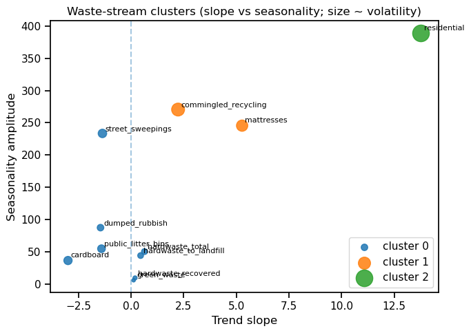

```python
plt.figure(figsize=(7,5))
for c in sorted(feat["cluster"].unique()):
    sel = feat["cluster"]==c
    plt.scatter(feat.loc[sel,"slope"], feat.loc[sel,"season"], s=10+feat.loc[sel,"vol"], label=f"cluster {c}", alpha=.85)
    for name in feat[sel].index:
        plt.annotate(name, (feat.loc[name,"slope"], feat.loc[name,"season"]), xytext=(3,3), textcoords="offset points", fontsize=8)
plt.axvline(0, ls="--", alpha=.4); plt.xlabel("Trend slope"); plt.ylabel("Seasonality amplitude")
plt.title("Waste-stream clusters (slope vs seasonality; size ~ volatility)")
plt.legend(); plt.tight_layout()
```

```python
# Build monthly features by joining your monthly totals, complaint counts, and SLA stats
M = aligned2[["total_waste","complaints"]].copy()
# add more monthly features if you have them: shares, p95, etc.

M = M.dropna()
Xs = StandardScaler().fit_transform(M)
km3 = KMeans(n_clusters=3, n_init="auto", random_state=0).fit(Xs)
M["month_cluster"] = km3.labels_
M.tail()
```

|  | total_waste | complaints | month_cluster |
| --- | --- | --- | --- |
| 20 | 2448.66 | 391 | 1 |
| 21 | 2708.16 | 529 | 2 |
| 22 | 2522.66 | 532 | 2 |
| 23 | 2630.11 | 408 | 0 |
| 24 | 2724.26 | 103 | 1 |

```python
from sklearn.ensemble import IsolationForest
iso = IsolationForest(random_state=0, contamination=0.05).fit(Xs)  # Xs from any feature set
out = iso.predict(Xs)
print("Anomalies:", M.index[out==-1].tolist() if hasattr(M,'index') else np.where(out==-1)[0])
```

```
Anomalies: [18, 24]
```

```python
# Run once per session
import os, numpy as np, pandas as pd, matplotlib.pyplot as plt
from sklearn.preprocessing import StandardScaler
from sklearn.linear_model import LinearRegression
from sklearn.metrics import mean_absolute_error, r2_score

OUT = "outputs"; os.makedirs(OUT, exist_ok=True)
pd.options.display.float_format = lambda x: f"{x:,.2f}"
```

```python
# Build clean monthly table aligned on 'date'
w = monthly_total.rename("total_waste").to_frame().rename_axis("date").reset_index()
c = comp_city[["date","complaints"]].copy()
w["date"] = pd.to_datetime(w["date"]); c["date"] = pd.to_datetime(c["date"])

aligned2 = (w.merge(c, on="date", how="inner")
              .groupby("date", as_index=False)
              .agg(total_waste=("total_waste","first"),
                   complaints=("complaints","sum"))
              .sort_values("date"))

# Drop last month if likely incomplete (fewest days)
if len(aligned2) > 1:
    last = aligned2["date"].max()
    if aligned2["date"].dt.to_period("M").max() == last.to_period("M") and last.day < 28:
        aligned2 = aligned2[aligned2["date"] != last]

aligned2.to_csv(f"{OUT}/monthly_waste_complaints.csv", index=False)
aligned2.tail(3)
```

|  | date | total_waste | complaints |
| --- | --- | --- | --- |
| 21 | 2016-08-01 | 2,708.16 | 529 |
| 22 | 2016-09-01 | 2,522.66 | 532 |
| 23 | 2016-10-01 | 2,630.11 | 408 |

### Project Conclusion & Next Steps — Waste Management and Health Risks

#### What the data says

- **Waste and complaints rise together.** When the amount of waste goes up in a month, complaints also go up, and often the following month as well.
- **Where help is needed first.** The suburbs that most need attention are **Melbourne**, **Carlton** and **West Melbourne** because they have many complaints and take longer to resolve them.
- **What drives the totals.** The biggest part of the waste is **Residential**. **Recycling** and **Mattresses** are also growing and add pressure.
- **When pressure is highest.** Months fall into clear groups: busy months, medium months, and quiet months. A few months look unusual and should be checked for special events or disruptions.
- **Health link (in this version).** We did not see a clear link between the chosen health measure and waste complaints. This may be because the data did not line up by year or there wasn’t enough variation.

#### Recommendations

- **Plan one month ahead.** If waste is high this month, get ready for more complaints next month by adding staff, routes, or hours.
- **Stabilise the hotspot suburbs.** Focus extra crews and quality checks in Melbourne, Carlton and West Melbourne. Look at missed collections and dumping in those areas first.
- **Focus on the biggest streams.** For Residential waste, consider larger bins or more frequent pickups in very busy streets and run simple “what goes in which bin” reminders. For Recycling, use quick feedback tags to cut contamination. For Mattresses, push booked kerbside pickup and store take-back.
- **Cut health risks directly.** Do regular clean-ups for dumped rubbish and sharps in known spots. During hot weather, collect organic/green waste faster to limit smells and pests.

#### What needs to be done

- **Save simple reports for hand-off.** Export: (1) monthly waste + complaints, (2) list of priority suburbs, (3) “top movers” by stream, (4) cluster results (months and suburbs), and (5) unusual months to review.
- **Set up a simple tracker.** A one-page view that shows waste, complaints, average days to close, long delays, and the current hotspot list.
- **Add a small forecast.** Use this month’s waste to give a next-month complaints number and a traffic-light warning (green/amber/red) so teams can prepare.
- **Turn month groups into a staffing plan.** For busy months: more routes and longer hours. For quiet months: training, vehicle maintenance, and clearing backlogs.
- **Clean joins.** Make sure suburb names match across tables, avoid using the last (incomplete) month for trends, and where possible use rates like “complaints per 10,000 people” instead of raw counts.

#### Enhancements

- **Line up years and use rates.** Match the year of health data and complaint data, and use “complaints per 10,000 people” to make fair comparisons between suburbs.
- **Add context.** Bring in weather (heat, rain), public holidays and big events to explain spikes and improve the forecast.
- **Map small hotspots.** Use the zone shapes to pinpoint problem blocks or alleys and target clean-ups there.
- **Measure changes.** When you run a campaign (e.g., contamination, mattresses), record before/after results so you know what works.
- **Make the notebook reliable.** Add timeouts/retries for downloads and save a local copy so it runs even if the website is slow.

#### Final conclusion

The data shows a clear pattern: **more waste leads to more complaints**, and we can use that to plan ahead. By preparing for busy months, focusing on the three hotspot suburbs, and managing the main waste streams (especially Residential and Recycling), the city can **reduce delays**, **prevent overflow and dumping**, and **lower health risks**. With a small forecast, a simple tracker, and regular clean-ups in the right places, these improvements are practical and achievable.

### References & Sources for *UC00198_Waste_Management_And_Health_Risks*

#### Data sources

- City of Melbourne — Open Data Portal: https://data.melbourne.vic.gov.au/
  - Waste Collected Per Month
  - Customer Service Requests With Resolution Time
  - Garbage collection zones
  - Social Indicators For City of Melbourne Residents 2023

#### Python libraries (documentation)

- Pandas (data wrangling, time series): https://pandas.pydata.org/docs/
- NumPy (arrays, linear algebra): https://numpy.org/doc/
- Matplotlib (visualisation, `pyplot`, `dates`): https://matplotlib.org/stable/
- Seaborn (statistical plots, e.g., `lineplot`, `barplot`): https://seaborn.pydata.org/
- Scikit-learn (models & metrics):
  - `KMeans`, `StandardScaler`, `silhouette_score`: [K-Means](https://scikit-learn.org/stable/modules/clustering.html#k-means), [StandardScaler](https://scikit-learn.org/stable/modules/generated/sklearn.preprocessing.StandardScaler.html), [Silhouette](https://scikit-learn.org/stable/modules/clustering.html#silhouette-coefficient)
  - `IsolationForest` (anomaly detection): [https://scikit-learn.org/…/isolation-forest](https://scikit-learn.org/stable/modules/outlier_detection.html#isolation-forest)
  - `LinearRegression` (simple forecast): [LinearRegression](https://scikit-learn.org/stable/modules/generated/sklearn.linear_model.LinearRegression.html)
- SciPy (correlation, `pearsonr`): [https://docs.scipy.org/…/pearsonr.html](https://docs.scipy.org/doc/scipy/reference/generated/scipy.stats.pearsonr.html)
- Requests (HTTP download/caching): https://requests.readthedocs.io/en/latest/
- Python (language reference): https://docs.python.org/3/